# IODS course project

Tina Lauronen

# Chapter 1: About the project

The course description is available in mooc.helsinki.fi

[Link to my github repository](https://github.com/tinalauronen/IODS-project)

# Chapter 2: Regression and model validation

*First look at data wrangling and analysis*

## Data wrangling

Reading the full data and naming it “learning2014”.

```r
learning2014 <- read.table("http://www.helsinki.fi/~kvehkala/JYTmooc/JYTOPKYS3-data.txt", sep="\t", header = TRUE)
```

Data consists of 183 rows (observations) and 60 columns (variables).

```r
dim(learning2014)
```

```
## [1] 183  60
```

The structure of the data:

```r
str(learning2014)
```

```
## 'data.frame':    183 obs. of  60 variables:
##  $ Aa      : int  3 2 4 4 3 4 4 3 2 3 ...
##  $ Ab      : int  1 2 1 2 2 2 1 1 1 2 ...
##  $ Ac      : int  2 2 1 3 2 1 2 2 2 1 ...
##  $ Ad      : int  1 2 1 2 1 1 2 1 1 1 ...
##  $ Ae      : int  1 1 1 1 2 1 1 1 1 1 ...
##  $ Af      : int  1 1 1 1 1 1 1 1 1 2 ...
##  $ ST01    : int  4 4 3 3 4 4 5 4 4 4 ...
##  $ SU02    : int  2 2 1 3 2 3 2 2 1 2 ...
##  $ D03     : int  4 4 4 4 5 5 4 4 5 4 ...
##  $ ST04    : int  4 4 4 4 3 4 2 5 5 4 ...
##  $ SU05    : int  2 4 2 3 4 3 2 4 2 4 ...
##  $ D06     : int  4 2 3 4 4 5 3 3 4 4 ...
##  $ D07     : int  4 3 4 4 4 5 4 4 5 4 ...
##  $ SU08    : int  3 4 1 2 3 4 4 2 4 2 ...
```

[output cut: 46 more lines]

Acces the dplyr library:

```r
library(dplyr)
```

Combinig the questions related to deep, surface and strategic learning.

```r
deep_questions <- c("D03", "D11", "D19", "D27", "D07", "D14", "D22", "D30","D07","D14","D22","D30")
surface_questions <-c("SU02","SU10","SU18","SU26", "SU05","SU13","SU21","SU29","SU08","SU16","SU24","SU32")
strategic_questions <- c("ST01","ST09","ST17","ST25","ST04","ST12","ST20","ST28")
```

Selecting the columns for “deep” and taking average to scale the variable.

```r
deep_columns <- select(learning2014, one_of(deep_questions))
learning2014$deep <- rowMeans(deep_columns)
```

Selecting the columns for “surf” and taking average to scale the variable.

```r
surface_columns <- select(learning2014, one_of(surface_questions))
learning2014$surf <- rowMeans(surface_columns)
```

Selecting the columns for “stra” and taking average to scale the variable.

```r
strategic_columns <- select(learning2014, one_of(strategic_questions))
learning2014$stra <- rowMeans(strategic_columns)
```

Selecting the variables gender, age, attitude towards statistics, exam points and the three new summary variables to dataset.

```r
keep_columns <- c("gender", "Age", "Attitude", "deep", "stra", "surf", "Points")
new_learning2014 <- select(learning2014, one_of(keep_columns))
```

Removing the observations with 0 exam points:

```r
new_learning2014 <- filter(new_learning2014, Points > 0)
```

Testing: The dimension and structure seem to be correct.

```r
dim(new_learning2014)
```

```
## [1] 166   7
```

```r
str(new_learning2014)
```

```
## 'data.frame':    166 obs. of  7 variables:
##  $ gender  : Factor w/ 2 levels "F","M": 1 2 1 2 2 1 2 1 2 1 ...
##  $ Age     : int  53 55 49 53 49 38 50 37 37 42 ...
##  $ Attitude: int  37 31 25 35 37 38 35 29 38 21 ...
##  $ deep    : num  3.75 2.88 3.88 3.5 3.75 ...
##  $ stra    : num  3.38 2.75 3.62 3.12 3.62 ...
##  $ surf    : num  2.58 3.17 2.25 2.25 2.83 ...
##  $ Points  : int  25 12 24 10 22 21 21 31 24 26 ...
```

Saving the dataset:

```r
write.table(new_learning2014, "learning2014.txt", sep = "\t")
```

```r
str(new_learning2014)
```

```
## 'data.frame':    166 obs. of  7 variables:
##  $ gender  : Factor w/ 2 levels "F","M": 1 2 1 2 2 1 2 1 2 1 ...
##  $ Age     : int  53 55 49 53 49 38 50 37 37 42 ...
##  $ Attitude: int  37 31 25 35 37 38 35 29 38 21 ...
##  $ deep    : num  3.75 2.88 3.88 3.5 3.75 ...
##  $ stra    : num  3.38 2.75 3.62 3.12 3.62 ...
##  $ surf    : num  2.58 3.17 2.25 2.25 2.83 ...
##  $ Points  : int  25 12 24 10 22 21 21 31 24 26 ...
```

```r
dim(new_learning2014)
```

```
## [1] 166   7
```

```r
head(new_learning2014)
```

```
##   gender Age Attitude  deep  stra     surf Points
## 1      F  53       37 3.750 3.375 2.583333     25
## 2      M  55       31 2.875 2.750 3.166667     12
## 3      F  49       25 3.875 3.625 2.250000     24
## 4      M  53       35 3.500 3.125 2.250000     10
## 5      M  49       37 3.750 3.625 2.833333     22
## 6      F  38       38 4.875 3.625 2.416667     21
```

…and everything seems to be ok and I’m able move forward to the analysis part of the exercises.

## Analysis

1. Describing the data

I’m using the dataset from the previous part of the exercise. The data is part of a larger “Approaches to Learning” -survey. Here is used only a few backgroud variables (age and gender), variable measuring global attitude toward statistics, exam points and sum variables measuring student’s deep, surface and strategic learning.

When observations with zero exam points are excluded, the total N of the data is 166.

2. Descriptive statistics

First thing to do with the data is to see some descriptive statistics.

```r
summary(new_learning2014)
```

```
##  gender       Age           Attitude          deep            stra
##  F:110   Min.   :17.00   Min.   :14.00   Min.   :1.625   Min.   :1.250
##  M: 56   1st Qu.:21.00   1st Qu.:26.00   1st Qu.:3.500   1st Qu.:2.625
##          Median :22.00   Median :32.00   Median :3.875   Median :3.188
##          Mean   :25.51   Mean   :31.43   Mean   :3.796   Mean   :3.121
##          3rd Qu.:27.00   3rd Qu.:37.00   3rd Qu.:4.250   3rd Qu.:3.625
##          Max.   :55.00   Max.   :50.00   Max.   :4.875   Max.   :5.000
##       surf           Points
##  Min.   :1.583   Min.   : 7.00
##  1st Qu.:2.417   1st Qu.:19.00
##  Median :2.833   Median :23.00
##  Mean   :2.787   Mean   :22.72
##  3rd Qu.:3.167   3rd Qu.:27.75
##  Max.   :4.333   Max.   :33.00
```

There are 110 female and 56 male respondents in the data. Tha average age is 25.5 when the youngest respondent is 17 and the oldest 55 years old. The measured mean attitude towards statistics is 31.4, ranging from 14 to 50. Exam points range (when 0 points excluded) from 7 to 33 and the average is 22.7. The summary variables measuring deep, strategic and surface learning are scaled from 1 to 5. In deep learning the averige is 3.8 (minimum 1.6, maximum 4.9), strategic learning 3.1 (min 1.3, max 5.0) and surface learning 2.8 (min 1.6, max 4.3).

As a graphical overview I made a scatter plot of all the variables according to background variables.

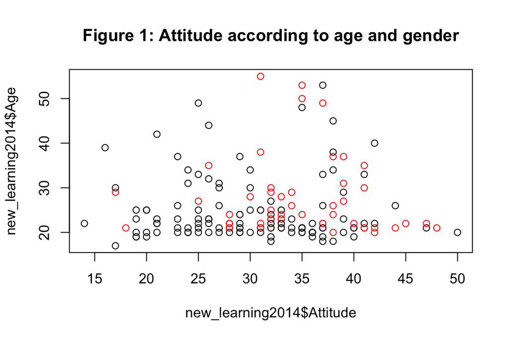

```r
plot(new_learning2014$Attitude, new_learning2014$Age, col=new_learning2014$gender, title("Figure 1: Attitude according to age and gender"))
```

Males and older respondents seem to have more attitude towards statistics.

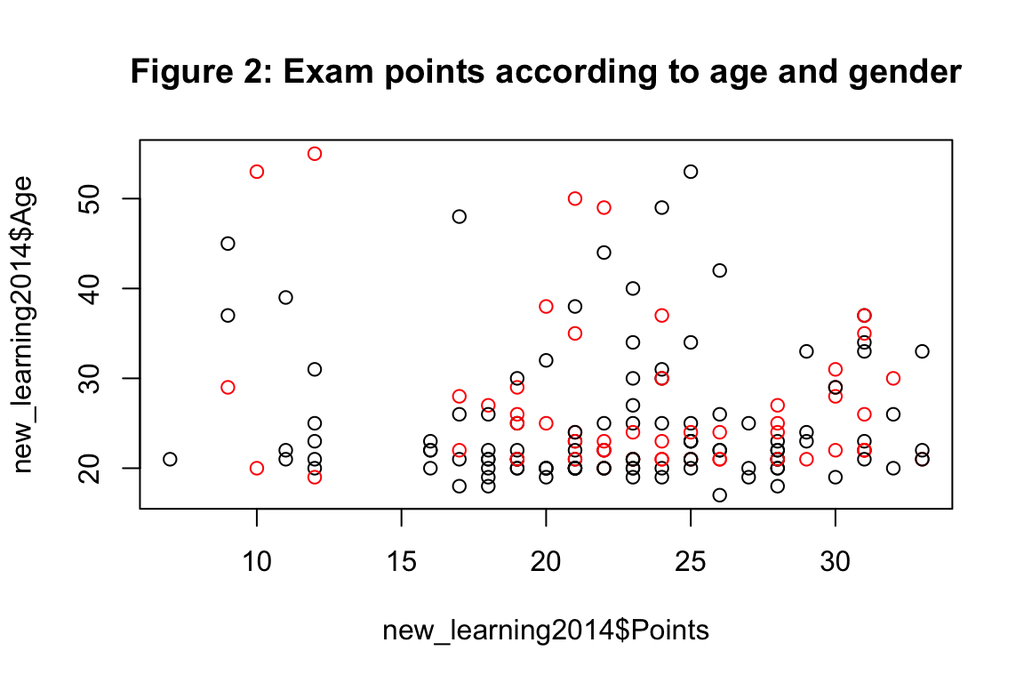

```r
plot(new_learning2014$Points, new_learning2014$Age, col=new_learning2014$gender, title("Figure 2: Exam points according to age and gender"))
```

There is a lot of variation in exam points, no clear trends visible. Especially in the lower points there are both genders and respondents of all ages represent.

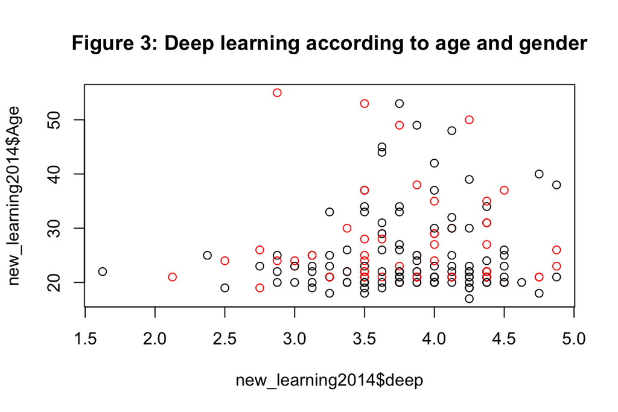

```r
plot(new_learning2014$deep, new_learning2014$Age, col=new_learning2014$gender, title("Figure 3: Deep learning according to age and gender"))
```

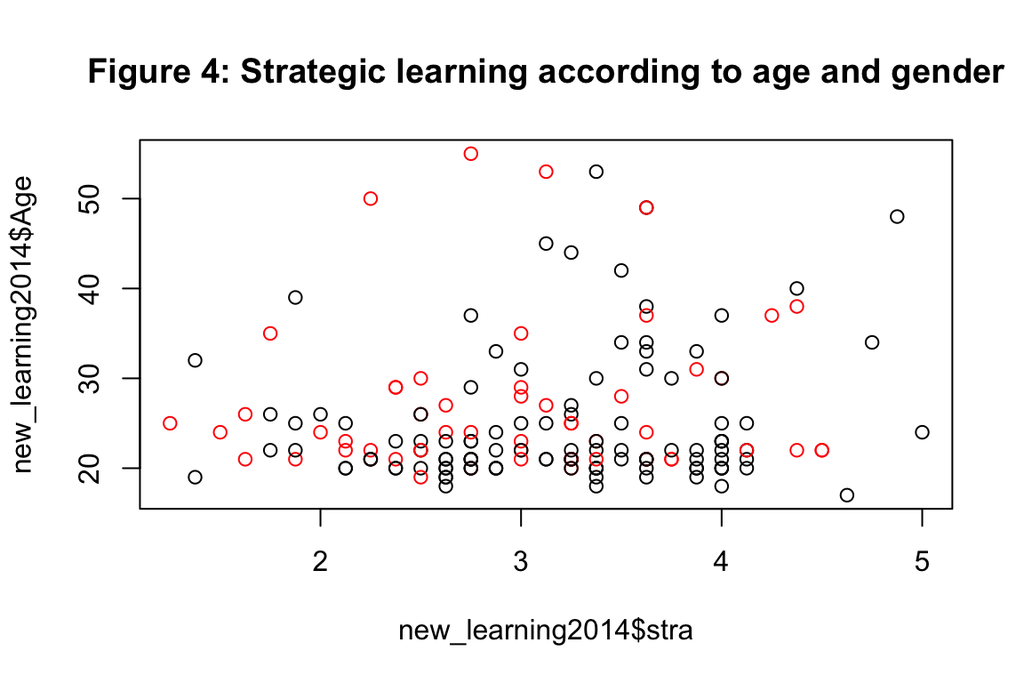

```r
plot(new_learning2014$stra, new_learning2014$Age, col=new_learning2014$gender, title("Figure 4: Strategic learning according to age and gender"))
```

In strategic learning the impact of age is not at visible as above, but some connection is visible.

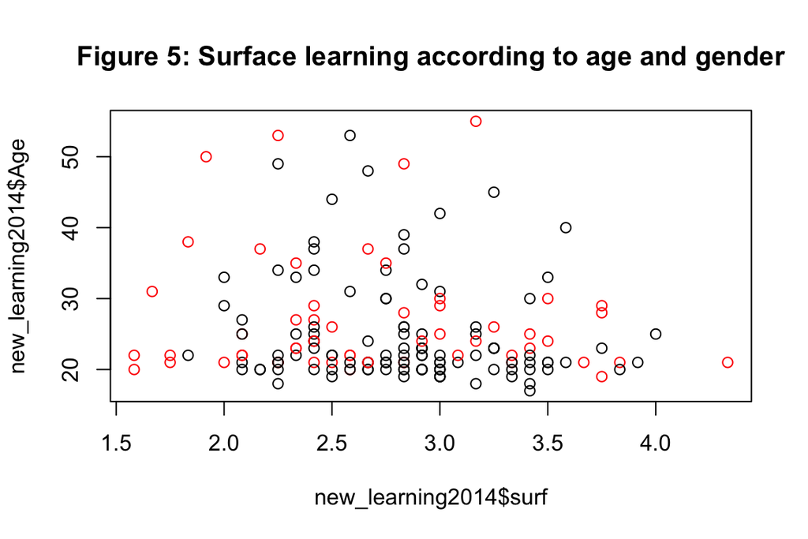

```r
plot(new_learning2014$surf, new_learning2014$Age, col=new_learning2014$gender, title("Figure 5: Surface learning according to age and gender"))
```

Surface learning is less usual than the other two, but surprisingly there are no clear differences according to age nor gender.

3. Regression model

Creating a regression model with three explanatory variables (attitude, deep learning and strategic learning). The dependent variable is exam points. Checking the summary of the model.

```r
rg_model <- lm(Points ~ Attitude + deep + stra, data = new_learning2014)
summary(rg_model)
```

```
##
## Call:
## lm(formula = Points ~ Attitude + deep + stra, data = new_learning2014)
##
## Residuals:
##     Min      1Q  Median      3Q     Max
## -17.525  -3.342   0.572   3.902  11.646
##
## Coefficients:
##             Estimate Std. Error t value Pr(>|t|)
## (Intercept) 12.05207    3.43928   3.504 0.000592 ***
## Attitude     0.35116    0.05654   6.211 4.27e-09 ***
## deep        -0.90243    0.72430  -1.246 0.214584
## stra         0.97852    0.53610   1.825 0.069805 .
## ---
## Signif. codes:  0 '***' 0.001 '**' 0.01 '*' 0.05 '.' 0.1 ' ' 1
##
## Residual standard error: 5.28 on 162 degrees of freedom
## Multiple R-squared:  0.2124, Adjusted R-squared:  0.1978
## F-statistic: 14.56 on 3 and 162 DF,  p-value: 1.925e-08
```

The summary table tells us that when attitude rises one point the exam point increses by 0.35 points. The similar connecton with deep learning is -0.90 and with strategic learning 0.98.

The only statistically significant variable is the attitude. I tried surface learning and both age and gender as well, but they were not statistically significant in the analysis. In this case I remove all the other variables but the attitude.

4. Summary of the fitted model

The final regression model is simple with only one independet, explanatory variable.

```r
rg_model2 <- lm(Points ~ Attitude, data = new_learning2014)
summary(rg_model2)
```

```
##
## Call:
## lm(formula = Points ~ Attitude, data = new_learning2014)
##
## Residuals:
##      Min       1Q   Median       3Q      Max
## -16.9763  -3.2119   0.4339   4.1534  10.6645
##
## Coefficients:
##             Estimate Std. Error t value Pr(>|t|)
## (Intercept) 11.63715    1.83035   6.358 1.95e-09 ***
## Attitude     0.35255    0.05674   6.214 4.12e-09 ***
## ---
## Signif. codes:  0 '***' 0.001 '**' 0.01 '*' 0.05 '.' 0.1 ' ' 1
##
## Residual standard error: 5.32 on 164 degrees of freedom
## Multiple R-squared:  0.1906, Adjusted R-squared:  0.1856
## F-statistic: 38.61 on 1 and 164 DF,  p-value: 4.119e-09
```

The effect of attitude stays the same as above: when the level of attitude grows one point, the exam points increse by 0.35 points. The effect is not very strong, but it is statistically significant, which means that there is very low change to make the wrong assumption about the relationship of these two variables.

5. Diagnostic plots

Residuals vs. Fitted values:

In this diagnostic plot we examine if the errors are just errors and not depending on the explanatory variable. This means that there should not be any kind of pattern in the plot - and luckily there is not.

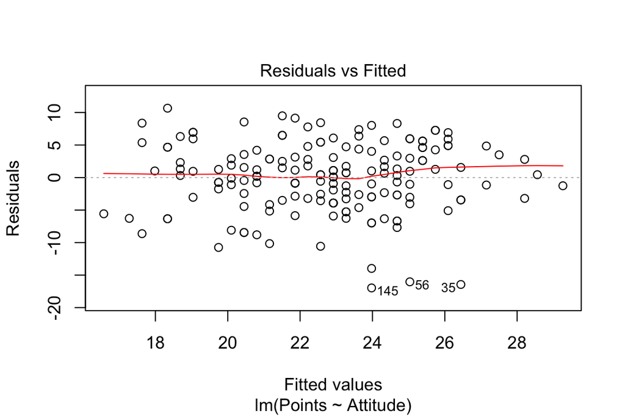

```r
plot(rg_model2, which = 1)
```

Normal QQ-plot:

The plot shows that the residuals are close enough normally distributed. The residuals follow the line quite well.

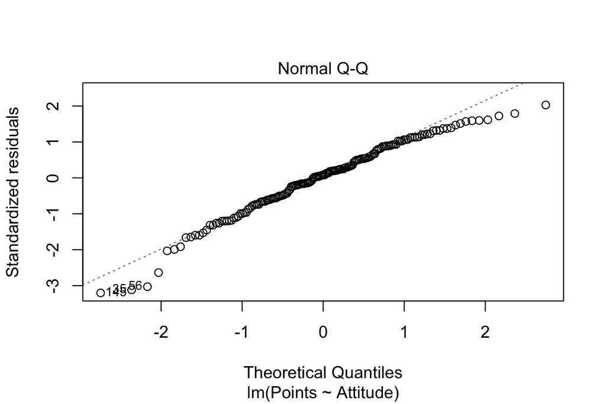

```r
plot(rg_model2, which = 2)
```

Residuals vs. Leverage:

In this plot we examine the impact of an individual observation on the model, basically by checking how far from the average are the (possible) observations that do not fit in the model. In this case there is nothing to worry.

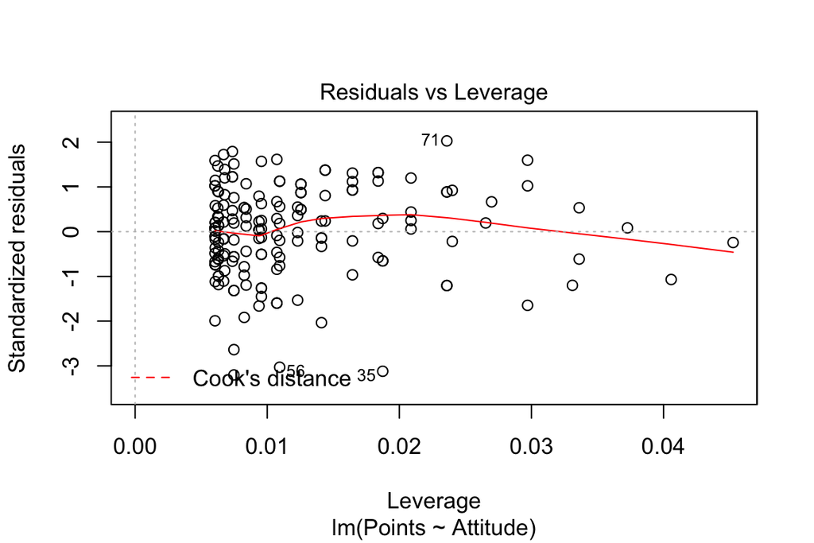

```r
plot(rg_model2, which = 5)
```

# Chapter 3: Logistic regression

## The data

The data set used in this exercise is joined dataset about student alcohol consumption. The data and some information about it is available [here](https://archive.ics.uci.edu/ml/datasets/STUDENT+ALCOHOL+CONSUMPTION). The data set is joined and motified in the previous data wrangling exercise. The RScript is available [here](https://github.com/tinalauronen/IODS-project/blob/master/data/create_alc.R). We start by reading the dataset from the file.

```r
alc <- read.csv("/Users/tlaurone/GitHub/tinalauronen/IODS-project/data/alc.csv")
```

```r
colnames(alc)
```

```
##  [1] "X"          "school"     "sex"        "age"        "address"
##  [6] "famsize"    "Pstatus"    "Medu"       "Fedu"       "Mjob"
## [11] "Fjob"       "reason"     "nursery"    "internet"   "guardian"
## [16] "traveltime" "studytime"  "failures"   "schoolsup"  "famsup"
## [21] "paid"       "activities" "higher"     "romantic"   "famrel"
## [26] "freetime"   "goout"      "Dalc"       "Walc"       "health"
## [31] "absences"   "G1"         "G2"         "G3"         "alc_use"
## [36] "high_use"
```

We also need some libraries to conduct the analyses.

```r
library(tidyr); library(dplyr); library(ggplot2); library(gmodels)
```

## The variables and hyphothesis

The dependent variable is *high alcohol consumption*. It is a dichotomy variable (true/false) counted from the variables measuring weekly and daily alcohol consumption (scale from 1 - very low to 5 - very high). If the average of those alcohol consumption variables is more than 2, the respondent is classified in the high consumption category. From the 382 respondents 114 are in the high usage category and 268 are not.

The independent (explanatory) variables chosen to this analysis are *sex*, *mother’s education*, *going out with friends* and *romantic relationship*.

## Distributions and preliminary analysis

There are 198 females and 184 males in the data. The assumption is that males consume more alcohol. *Mother’s education* is measured on a five step scale (0 = no education, 1 = primary education, 2 = 5th or 9th grade, 3 = secondary education, 4 = higher education). The assumption is that the more educated the mother is, the less the student uses alcohol.

*Going out with friends* is measured by a scale from 1 (very low) to 5 (very heigh). The assumption is that the more student goes out with friends, the more s/he uses alcohol. *Romantic relationship* is measured as a simple dichotomy, yes or no. The assumption is that romantic relationship decreases the alcohol consumption.

The connection between *sex* and *high alcohol consumption* is easiest to explore by cross tabulation. Below we can see, that 39.1 % of male respondents are considered high users, compared to only 21.2 % of females. Of all high users 63.2 % are male and 36.8 % female. The results are statistically significant (p<0.001).

```r
CrossTable(alc$high_use, alc$sex, prop.r = TRUE, prop.c = TRUE, prop.t = FALSE, prop.chisq = FALSE, chisq = TRUE)
```

```
##
##
##    Cell Contents
## |-------------------------|
## |                       N |
## |           N / Row Total |
## |           N / Col Total |
## |-------------------------|
##
##
## Total Observations in Table:  382
##
##
##              | alc$sex
## alc$high_use |         F |         M | Row Total |
## -------------|-----------|-----------|-----------|
##        FALSE |       156 |       112 |       268 |
##              |     0.582 |     0.418 |     0.702 |
##              |     0.788 |     0.609 |           |
## -------------|-----------|-----------|-----------|
##         TRUE |        42 |        72 |       114 |
##              |     0.368 |     0.632 |     0.298 |
##              |     0.212 |     0.391 |           |
## -------------|-----------|-----------|-----------|
## Column Total |       198 |       184 |       382 |
##              |     0.518 |     0.482 |           |
## -------------|-----------|-----------|-----------|
##
##
## Statistics for All Table Factors
##
##
## Pearson's Chi-squared test
## ------------------------------------------------------------
## Chi^2 =  14.62517     d.f. =  1     p =  0.000131151
##
## Pearson's Chi-squared test with Yates' continuity correction
## ------------------------------------------------------------
## Chi^2 =  13.78187     d.f. =  1     p =  0.0002053081
##
##
```

To present the distribution of the other independent variables and their connections to the dependent variable, we use simple bar plots.

In Figure 1 there is the distribution of variable *mother’s education* presented. By adding the high alcohol use variable in the figure, it is possible to see that there is some connection between the variables: compared to primary education it is less likely that children of bit more educated mothers are less likely high users of alcohol. Secondary education increses the share of high drinkers, but again the higher education seems to have connection to less usage.

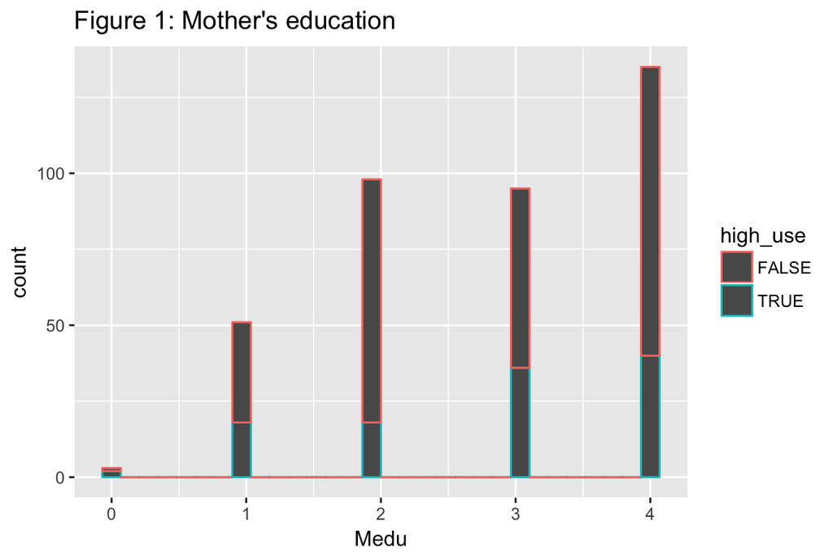

```r
qplot(Medu, data = alc, color = high_use, main = "Figure 1: Mother's education")
```

Figure 2 presents the frequencies of the variable *going out with friends* and its connections to high alcohol usage. As assumed, the more students go out with friends the more likely they use more alcohol.

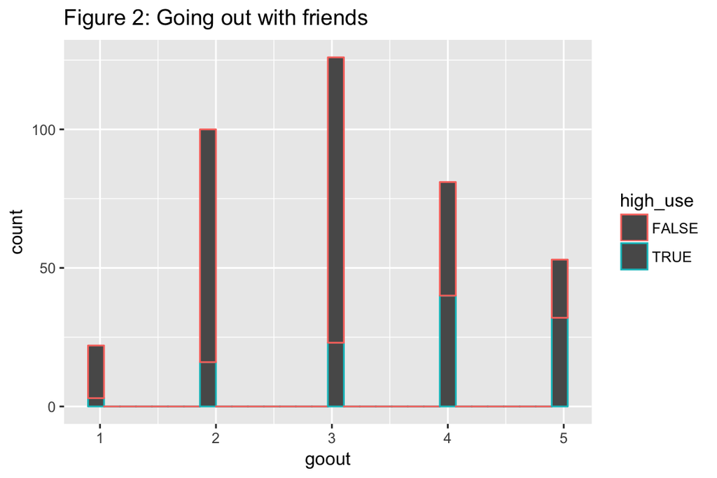

```r
qplot(goout, data = alc, color = high_use, main = "Figure 2: Going out with friends")
```

In Figure 3 there is no clear, visible diffenrence in high alcohol consumption an romantic relationships because the amount of students not in a relationship is so much higher.

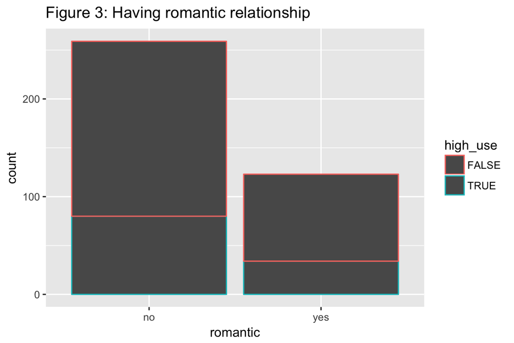

```r
qplot(romantic, data = alc, color = high_use, main = "Figure 3: Having romantic relationship")
```

Simple cross tabulations or bar plot are not sufficient methods to approach a question as complicated as high alcohol consumption. It is necessary to move forward to more sophisticated methods.

## Logistic regression analysis

Using the variables presented above we conduct a logistic regression analysis to explore high alcohol usage. First we make the model and print the summary of it, then we compute and print odds ratios (OR) and confidence intervals (CI).

```r
r_model <- glm(high_use ~ sex + Medu + goout + romantic, data = alc, family = "binomial")
summary.glm(r_model)
```

```
##
## Call:
## glm(formula = high_use ~ sex + Medu + goout + romantic, family = "binomial",
##     data = alc)
##
## Deviance Residuals:
##     Min       1Q   Median       3Q      Max
## -1.6002  -0.8624  -0.6150   0.8460   2.5276
##
## Coefficients:
##             Estimate Std. Error z value Pr(>|z|)
## (Intercept) -3.63037    0.54119  -6.708 1.97e-11 ***
## sexM         0.87723    0.24830   3.533 0.000411 ***
## Medu        -0.05562    0.11326  -0.491 0.623384
## goout        0.76382    0.11819   6.463 1.03e-10 ***
## romanticyes -0.11913    0.26591  -0.448 0.654154
## ---
## Signif. codes:  0 '***' 0.001 '**' 0.01 '*' 0.05 '.' 0.1 ' ' 1
##
## (Dispersion parameter for binomial family taken to be 1)
##
##     Null deviance: 465.68  on 381  degrees of freedom
## Residual deviance: 402.30  on 377  degrees of freedom
## AIC: 412.3
##
## Number of Fisher Scoring iterations: 4
```

```r
OR <- coef(r_model) %>% exp
CI <- confint(r_model) %>% exp
cbind(OR, CI)
```

```
##                     OR       2.5 %     97.5 %
## (Intercept) 0.02650637 0.008790626 0.07374126
## sexM        2.40422513 1.484855219 3.93774659
## Medu        0.94590023 0.757602427 1.18226671
## goout       2.14645372 1.712829640 2.72499480
## romanticyes 0.88769573 0.523308804 1.48804026
```

From the coefficient table from the summary we can see, that only *sex* and *going out with friends* are statistically significant variables explaining the high alcohol usage. From the OR table we are able to interpret that if a student is a male (versus being a female) he is 2.4 times more likely a high user. *Going out with friends* adds the probability to be a high user as well, but due to the measurement scale of the variable the interpretation is not as straightforward.

If not considering the statistical significance levels it is possible to simplify the interpretation of the OR’s: If the OR is less than 1, it is less likely to be a high user. This would mean in our case that more educated mother and being in a romantic relationship would decrese the probability to use more alcohol. Insted, being a male and going out with friends a lot increses that probability - and the effect is stronger as well. These results are in line with the preassumptions - but there is no reason to claim that in case of *mother’s education* and *romantic relationship*.

## Predictions

First we create a new regression model with the statistically significant variables, *sex* and *going out with friends* from the previous model. Then we make a new variable: first one that contains the prediction, then one that predicts high alcohol usage.

```r
r_m <- glm(high_use ~ sex + goout, data = alc, family = "binomial")
probabilities <- predict(r_m, type = "response")
alc <- mutate(alc, probability = probabilities)
alc <- mutate(alc, prediction = (probability > 0.5))
```

Then we make a table of the original variable, *high alcohol usage*, and the variable predicting it.

```r
table(high_use = alc$high_use, prediction = alc$prediction)
```

```
##         prediction
## high_use FALSE TRUE
##    FALSE   251   17
##    TRUE     63   51
```

…and here is the same comparison in a graphical form:

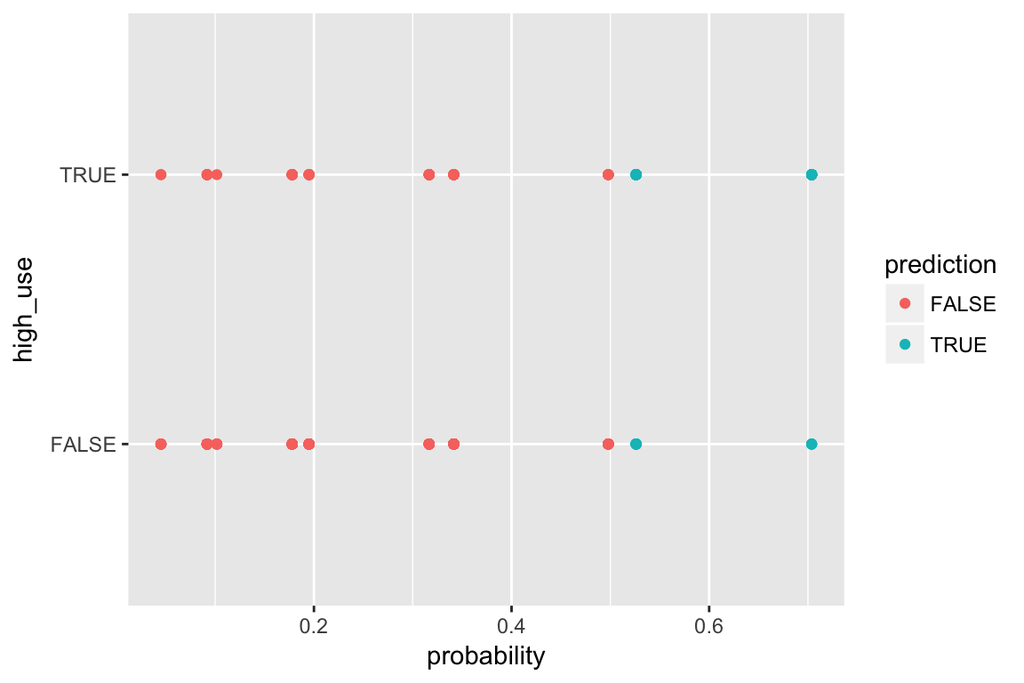

```r
g <- ggplot(alc, aes(x = probability, y = high_use, col = prediction))
g + geom_point()
```

Here we compute the proportion of inaccurately classified individuals. First we create a function to claculate the training error, the we do the actual math.

```r
loss_func <- function(class, prob) {
  n_wrong <- abs(class - prob) > 0.5
  mean(n_wrong)
}

loss_func(class = alc$high_use, prob = alc$probability)
```

```
## [1] 0.2094241
```

## K-fold cross-validation

Finally we test our model with K-fold cross-validation.

```r
library(boot)
cv <- cv.glm(data = alc, cost = loss_func, glmfit = r_m, K = 10)
cv$delta[1]
```

```
## [1] 0.2303665
```

The cross-validation exercise in DataCamp resulted error value of 0.26. Here the error value is approximately 0.23 which means that our model is better.